# Homework 2

## Image 2

```r
x <- read_csv("image2.csv")
x <- data.matrix(x)
```

### Original + Rank 1-10 Approximations

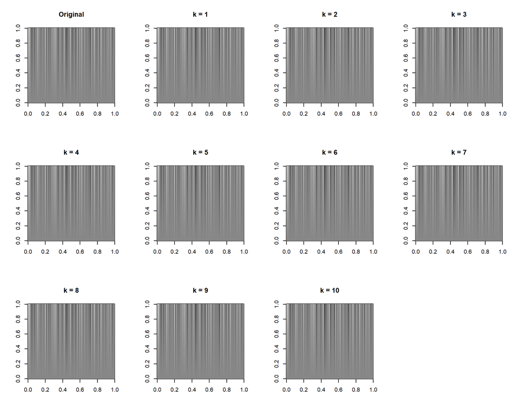

```r
par(mfrow = c(3, 4))
image(x, col = grey(seq(0,1,length=256)), main = "Original")
for (k in 1:10) {
  result <- compress_image(x, k)
  image(result$approximation, col = grey(seq(0,1,length=256)), main = paste("k =", k))
}
```

### Error vs. k

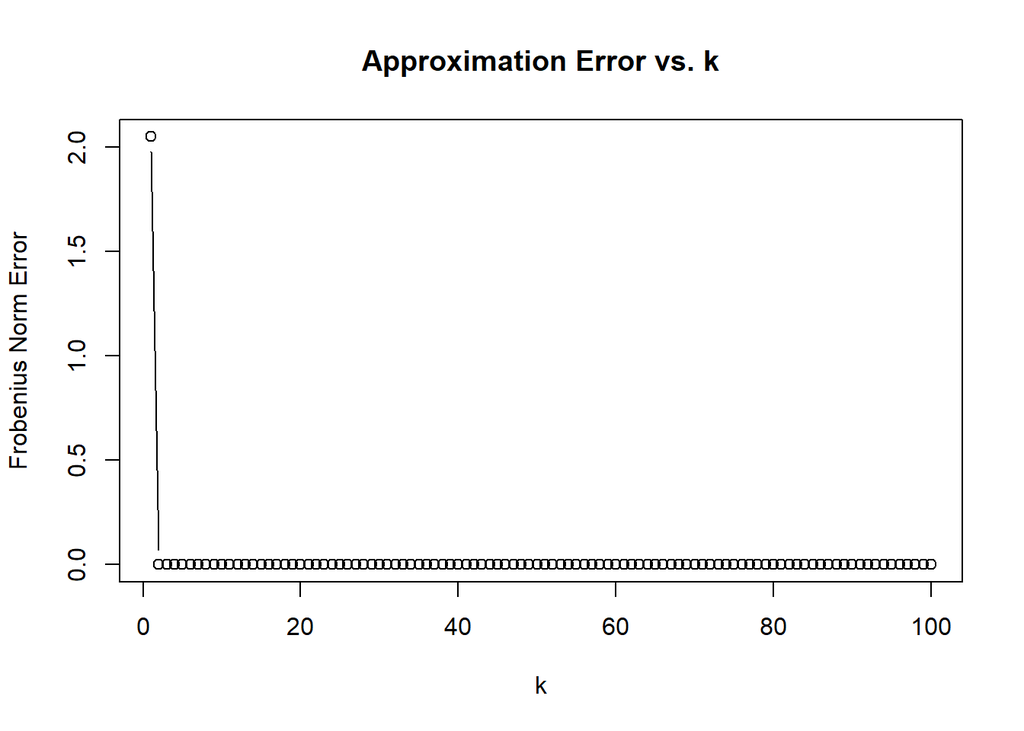

```r
max_k <- min(nrow(x), ncol(x))
errors <- sapply(1:max_k, function(k) compress_image(x, k)$error)
plot(1:max_k, errors, type = "b", xlab = "k", ylab = "Frobenius Norm Error",
     main = "Approximation Error vs. k")
```

### First Eigenvector and First PC Score

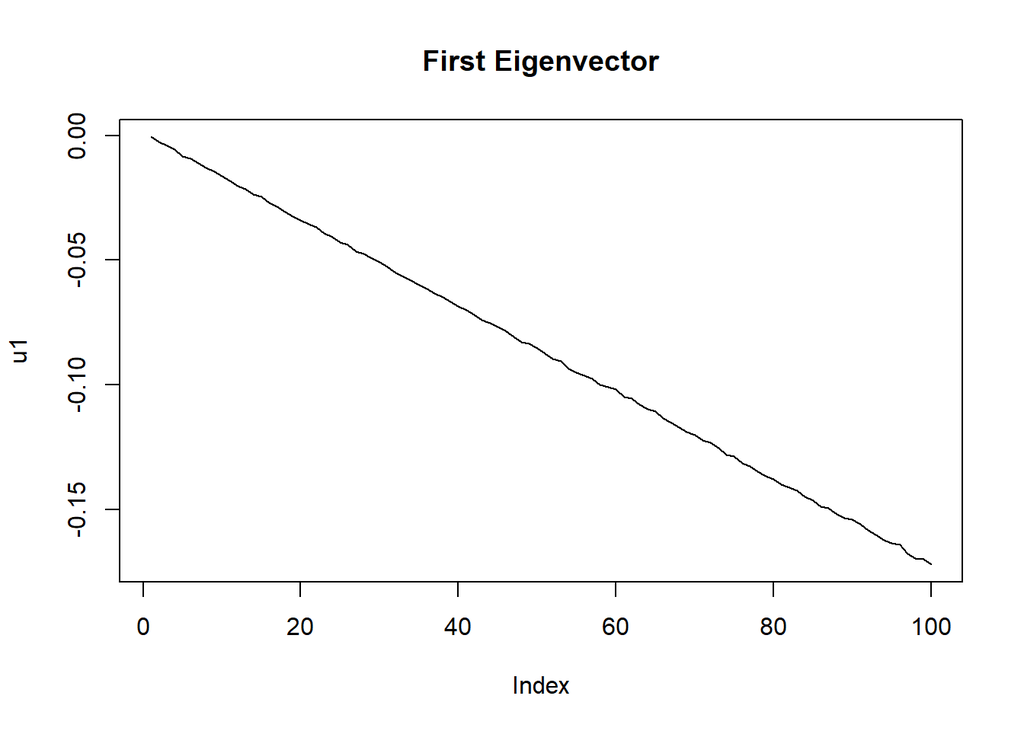

```r
V <- t(x) %*% x
eig <- eigen(V)
u1 <- eig$vectors[,1]
z1 <- (x %*% eig$vectors)[,1]

plot(u1, type = "l", main = "First Eigenvector")
```

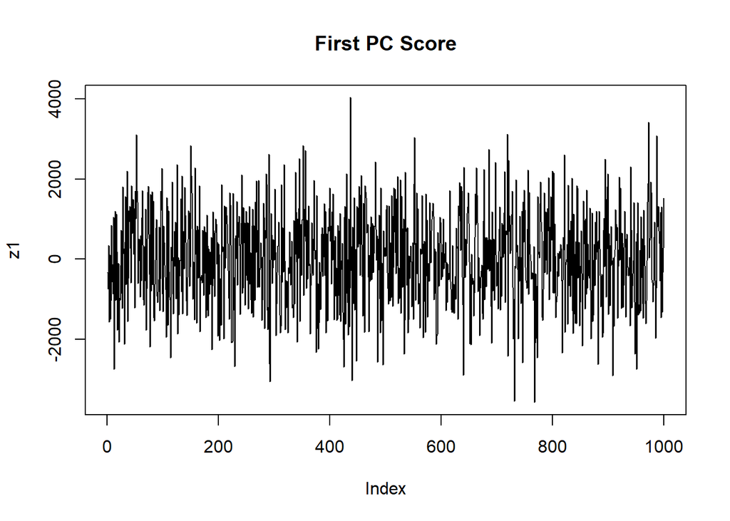

```r
plot(z1, type = "l", main = "First PC Score")
```

**Interpretation:** The first eigenvector is a smooth, steadily declining line with no sharp features, showing a mild, consistent contrast trend from left to right. The first PC score jumps around a lot from row to row, but the scale is big compared to u1, meaning almost all of the image’s pattern is explained by this one component. This matches the k=1 through k=10 images all looking basically identical to the original.

## Image 3

```r
x <- read_csv("image3.csv")
x <- data.matrix(x)
```

### Original + Rank 1-10 Approximations

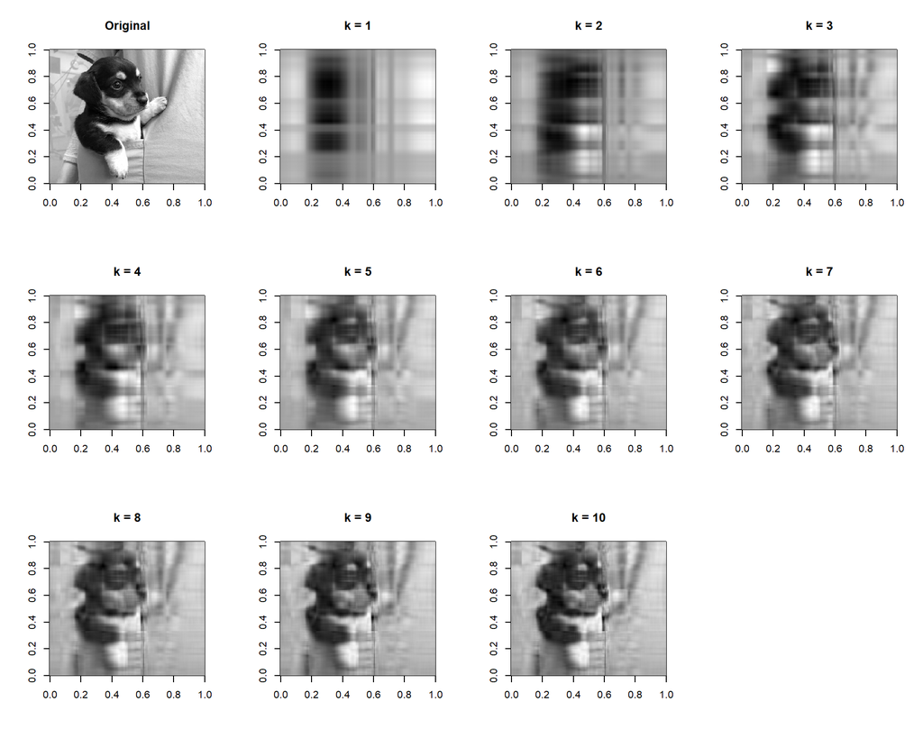

```r
par(mfrow = c(3, 4))
image(x, col = grey(seq(0,1,length=256)), main = "Original")
for (k in 1:10) {
  result <- compress_image(x, k)
  image(result$approximation, col = grey(seq(0,1,length=256)), main = paste("k =", k))
}
```

### Error vs. k

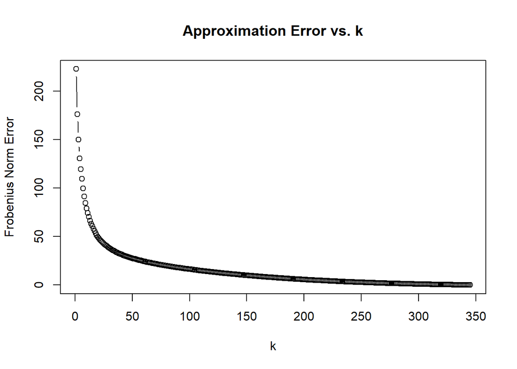

```r
max_k <- min(nrow(x), ncol(x))
errors <- sapply(1:max_k, function(k) compress_image(x, k)$error)
plot(1:max_k, errors, type = "b", xlab = "k", ylab = "Frobenius Norm Error",
     main = "Approximation Error vs. k")
```